# ML.ENERGY Phase 3.0 — hardware-aware high-load GPU inference modeling

## tl;dr

- In an outcome-informed exploratory comparison on the 305-run physics-complete cohort, **B4-Hardware + XGBoost** has model-holdout MAE **204.4 W**, RMSE **370.6 W**, R² **0.960**, and MdAPE **8.6%**.
- Relative to the historical B0-Core + HGB control, its observed model-holdout MAE difference is **−48.9 W**. This is not a winner-adjusted confirmatory estimate because the candidate was followed up after inspecting outer-test results.
- B5 normalized pressure proxies do **not** improve the exploratory XGBoost candidate: MAE rises to **241.7 W**. B4 shows learner-dependent signal, but the two-GPU support cannot establish broad hardware scaling laws.
- Difficulty matters more than headline random-split accuracy: B4 + XGBoost averages **97.2 W** MAE over ten random splits, reaches **94.7 W** for config holdout and **204.4 W** for model holdout, then degrades to **736.7 W** for family holdout.
- Energy/token remains harder: B1 + XGBoost gives **0.620 J/token** MAE and R² **0.677**; log1p removes the single negative raw prediction but slightly worsens MAE to **0.650 J/token**.

This notebook is a read-only companion to frozen result artifacts. It performs no model fitting.

## Scope and provenance

Only ML.ENERGY Benchmark V3 **GPU-side text-LLM inference** is in scope. Inputs are known before execution; post-run batch/load, throughput, latency, duration, utilization, and targets are diagnostic-only. The population represents **high-load steady-state / near-saturation** runs, not arbitrary request-rate dynamics.

Pinned inputs and training provenance are recorded in `step5/config/source_freeze_phase3.json` and `step5/analysis/training_provenance.json`. Hardware-profile evidence is recorded in `step5/config/hardware_source_manifest.json`; H100/B200 SKU mappings remain explicitly `ambiguous`.

```python
from pathlib import Path
import json
import numpy as np
import pandas as pd
from IPython.display import Image, display

ROOT = Path.cwd()
assert (ROOT / "step5").exists(), "Execute from the repository root"
STEP5 = ROOT / "step5"
REPORTS = STEP5 / "reports"
FIGURES = REPORTS / "figures"

comparison = pd.read_csv(REPORTS / "model_comparison.csv")
ablation = pd.read_csv(REPORTS / "feature_ablation.csv")
generalization = pd.read_csv(REPORTS / "generalization_ladder.csv")
hardware = pd.read_csv(REPORTS / "hardware_label_sensitivity.csv")
hardware_pairs = pd.read_csv(REPORTS / "hardware_paired_comparisons.csv")
strategies = pd.read_csv(REPORTS / "target_strategy_comparison.csv")
slices = pd.read_csv(REPORTS / "error_slices.csv")
importance = pd.read_csv(REPORTS / "feature_importance.csv")
coverage = pd.read_csv(STEP5 / "analysis/physics_coverage_summary.csv")
pca = pd.read_csv(STEP5 / "analysis/physics_pca_summary.csv")
source_freeze = json.loads((STEP5 / "config/source_freeze_phase3.json").read_text(encoding="utf-8"))
provenance = json.loads((STEP5 / "analysis/training_provenance.json").read_text(encoding="utf-8"))

pd.Series({
    "pinned inputs": len(source_freeze["frozen_inputs"]),
    "core experiments": provenance["completed_experiments"],
    "core OOF rows": provenance["prediction_rows"],
    "physics cohort rows": int(hardware["n_rows"].iloc[0]),
    "hardware sensitivity rows": len(hardware),
}).to_frame("value")
```

|  | value |
| --- | --- |
| pinned inputs | 10 |
| core experiments | 120 |
| core OOF rows | 36600 |
| physics cohort rows | 305 |
| hardware sensitivity rows | 4 |

## Physics coverage

The B3/B5 physics quantities are not constant, but their geometry is low-dimensional. On log1p-transformed, standardized values, PCA components 1–3 explain 82.1% and components 1–5 explain 95.8% of variance. Hardware-static fields have only two support values because the benchmark contains only H100 and B200 labels. This limits identifiability even when a hardware feature improves prediction.

|  | component | explained_variance_ratio | cumulative_explained_variance_ratio | transform | n_rows | n_features |
| --- | --- | --- | --- | --- | --- | --- |
| 0 | 1 | 0.4193 | 0.4193 | log1p_then_standardize | 305 | 26 |
| 1 | 2 | 0.2712 | 0.6905 | log1p_then_standardize | 305 | 26 |
| 2 | 3 | 0.1303 | 0.8209 | log1p_then_standardize | 305 | 26 |
| 3 | 4 | 0.0902 | 0.9110 | log1p_then_standardize | 305 | 26 |
| 4 | 5 | 0.0465 | 0.9575 | log1p_then_standardize | 305 | 26 |
| 5 | 6 | 0.0154 | 0.9729 | log1p_then_standardize | 305 | 26 |
| 6 | 7 | 0.0086 | 0.9815 | log1p_then_standardize | 305 | 26 |
| 7 | 8 | 0.0076 | 0.9891 | log1p_then_standardize | 305 | 26 |

|  | feature | feature_group | n_unique | p5 | median | p95 | cv | log10_range |
| --- | --- | --- | --- | --- | --- | --- | --- | --- |
| 17 | x_hardware_rated_power_w | B5 | 2 | 7.000000e+02 | 1.000000e+03 | 1.000000e+03 | 0.1731 | 0.1549 |
| 18 | x_hardware_interconnect_bandwidth_gbps | B5 | 2 | 9.000000e+02 | 1.800000e+03 | 1.800000e+03 | 0.3225 | 0.3010 |
| 16 | x_hardware_hbm_capacity_gb | B5 | 2 | 8.000000e+01 | 1.800000e+02 | 1.800000e+02 | 0.3705 | 0.3522 |
| 12 | x_hardware_peak_compute_bf16_dense_tflops | B5 | 2 | 9.895000e+02 | 2.250000e+03 | 2.250000e+03 | 0.3747 | 0.3568 |
| 13 | x_hardware_peak_compute_fp8_dense_tflops | B5 | 2 | 1.979000e+03 | 4.500000e+03 | 4.500000e+03 | 0.3747 | 0.3568 |
| 15 | x_hardware_hbm_bandwidth_gbps | B5 | 2 | 3.350000e+03 | 8.000000e+03 | 8.000000e+03 | 0.3938 | 0.3780 |
| 14 | x_hardware_precision_matched_peak_compute_tflops | B5 | 4 | 9.895000e+02 | 2.250000e+03 | 4.500000e+03 | 0.5249 | 0.6578 |
| 11 | x_physics_decode_one_token_flop_per_request_max | B3 | 14 | 9.372697e+09 | 5.037962e+10 | 8.286477e+10 | 0.5976 | 1.0359 |
| 19 | x_hardware_aggregate_rated_power_w | B5 | 8 | 7.000000e+02 | 1.400000e+03 | 8.000000e+03 | 0.9144 | 1.0580 |
| 4 | x_physics_prefill_total_flop_per_input_token | B3 | 14 | 6.828892e+09 | 4.311807e+10 | 7.249025e+10 | 0.6185 | 1.0988 |

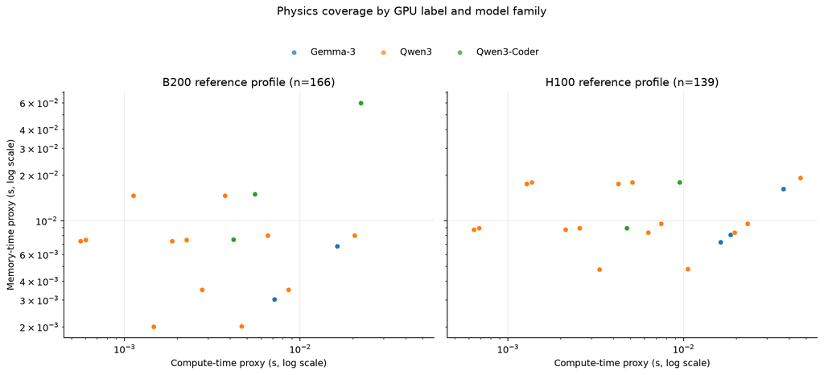

```python
display(pca.head(8).round(4))
display(
    coverage.sort_values("log10_range")
    [["feature", "feature_group", "n_unique", "p5", "median", "p95", "cv", "log10_range"]]
    .head(10).round(4)
)
display(Image(filename=str(FIGURES / "physics_coverage_by_gpu_family.png"), width=1000))
```

## Algorithm and feature matrix

The core matrix contains 120 matched experiments: two targets × six feature bundles × ten algorithms, all on the same 305 runs and frozen five model-group folds. Hyperparameters were selected only inside each outer-training partition. B4 is included for every learner, so B3→B4→B5 can be inspected without learner-specific omission. Ranking these outer-test results remains exploratory; they are not used for an unbiased winner estimate.

```python
power = comparison.loc[comparison["target"].eq("y_gpu_avg_power_watts")]
energy = comparison.loc[comparison["target"].eq("y_gpu_energy_per_token_joules")]
display(power.sort_values("mae")[["bundle", "model_name", "mae", "rmse", "r2", "mdape_percent", "mae_ci_low", "mae_ci_high"]].head(12).round(3))
display(energy.sort_values("mae")[["bundle", "model_name", "mae", "rmse", "r2", "mdape_percent", "mae_ci_low", "mae_ci_high"]].head(8).round(3))

b3_increment = ablation.loc[
    ablation["target"].eq("y_gpu_avg_power_watts")
    & ablation["reference_bundle"].eq("B2b-Effective")
]
display(b3_increment[["model_name", "mae_reference", "mae_candidate", "mae_delta_candidate_minus_reference", "equal_model_mae_delta_ci_low", "equal_model_mae_delta_ci_high"]].sort_values("mae_delta_candidate_minus_reference").round(3))
```

|  | bundle | model_name | mae | rmse | r2 | mdape_percent | mae_ci_low | mae_ci_high |
| --- | --- | --- | --- | --- | --- | --- | --- | --- |
| 49 | B4-Hardware | XGBoost | 204.366 | 370.649 | 0.960 | 8.573 | 110.251 | 335.113 |
| 19 | B1-Static | XGBoost | 237.852 | 391.147 | 0.956 | 11.267 | 145.374 | 375.482 |
| 39 | B3-Physics | XGBoost | 237.866 | 379.592 | 0.958 | 10.568 | 141.756 | 363.107 |
| 10 | B1-Static | CatBoost | 237.977 | 358.138 | 0.963 | 11.035 | 154.470 | 351.617 |
| 59 | B5-HardwarePhysics | XGBoost | 241.746 | 443.548 | 0.943 | 10.363 | 128.959 | 404.285 |
| 20 | B2b-Effective | CatBoost | 243.843 | 372.649 | 0.960 | 12.698 | 142.287 | 365.518 |
| 0 | B0-Core | CatBoost | 247.441 | 409.321 | 0.952 | 11.460 | 153.219 | 389.070 |
| 4 | B0-Core | HistGradientBoosting | 253.287 | 423.116 | 0.948 | 11.890 | 147.308 | 414.596 |
| 29 | B2b-Effective | XGBoost | 254.624 | 434.860 | 0.945 | 10.121 | 150.555 | 410.670 |
| 9 | B0-Core | XGBoost | 255.337 | 402.867 | 0.953 | 11.243 | 155.055 | 393.232 |
| 14 | B1-Static | HistGradientBoosting | 274.954 | 449.216 | 0.942 | 12.715 | 163.660 | 436.007 |
| 44 | B4-Hardware | HistGradientBoosting | 276.957 | 502.438 | 0.927 | 11.854 | 153.025 | 439.334 |

|  | bundle | model_name | mae | rmse | r2 | mdape_percent | mae_ci_low | mae_ci_high |
| --- | --- | --- | --- | --- | --- | --- | --- | --- |
| 79 | B1-Static | XGBoost | 0.620 | 2.114 | 0.677 | 24.213 | 0.181 | 1.515 |
| 69 | B0-Core | XGBoost | 0.633 | 2.112 | 0.677 | 26.749 | 0.192 | 1.463 |
| 99 | B3-Physics | XGBoost | 0.654 | 2.130 | 0.672 | 24.691 | 0.203 | 1.508 |
| 89 | B2b-Effective | XGBoost | 0.655 | 2.219 | 0.644 | 27.311 | 0.197 | 1.633 |
| 60 | B0-Core | CatBoost | 0.670 | 2.130 | 0.672 | 26.835 | 0.201 | 1.649 |
| 109 | B4-Hardware | XGBoost | 0.683 | 2.149 | 0.666 | 26.290 | 0.213 | 1.625 |
| 64 | B0-Core | HistGradientBoosting | 0.691 | 2.259 | 0.631 | 27.500 | 0.209 | 1.653 |
| 74 | B1-Static | HistGradientBoosting | 0.704 | 2.239 | 0.637 | 26.191 | 0.212 | 1.649 |

|  | model_name | mae_reference | mae_candidate | mae_delta_candidate_minus_reference | equal_model_mae_delta_ci_low | equal_model_mae_delta_ci_high |
| --- | --- | --- | --- | --- | --- | --- |
| 47 | XGBoost | 254.624 | 237.866 | -16.757 | -112.024 | 11.122 |
| 7 | DummyMean | 1657.163 | 1657.163 | 0.000 | 0.000 | 0.000 |
| 22 | HistGradientBoosting | 281.897 | 296.375 | 14.478 | -8.405 | 44.858 |
| 17 | ExtraTrees | 311.705 | 342.702 | 30.997 | -8.310 | 80.335 |
| 27 | RandomForest | 311.744 | 349.555 | 37.811 | -3.513 | 88.267 |
| 2 | CatBoost | 243.843 | 298.527 | 54.685 | 2.611 | 131.292 |
| 12 | ElasticNet | 398.052 | 483.608 | 85.555 | -19.017 | 189.303 |
| 42 | SplineGAM | 439.193 | 539.278 | 100.085 | -37.495 | 304.640 |
| 32 | Ridge | 397.799 | 520.335 | 122.536 | -10.977 | 272.942 |
| 37 | SmallMLP | 747.698 | 1534.500 | 786.802 | -165.711 | 2489.308 |

## Generalization ladder

Random/config results describe interpolation or known-model configuration transfer. Model holdout is the primary scientific estimate for unseen models. Family holdout is a stress test and exposes the major unresolved failure mode.

|  | model_variant | split_scheme | runs | mae_mean | mae_std | r2_mean |
| --- | --- | --- | --- | --- | --- | --- |
| 0 | B0-Core__HistGradientBoosting | config_group | 1 | 132.800 | NaN | 0.990 |
| 1 | B0-Core__HistGradientBoosting | family_group | 1 | 672.024 | NaN | 0.672 |
| 2 | B0-Core__HistGradientBoosting | model_group | 1 | 253.287 | NaN | 0.948 |
| 3 | B0-Core__HistGradientBoosting | random | 10 | 130.042 | 24.931 | 0.987 |
| 4 | B4-Hardware__XGBoost | config_group | 1 | 94.671 | NaN | 0.992 |
| 5 | B4-Hardware__XGBoost | family_group | 1 | 736.699 | NaN | 0.590 |
| 6 | B4-Hardware__XGBoost | model_group | 1 | 204.366 | NaN | 0.960 |
| 7 | B4-Hardware__XGBoost | random | 10 | 97.184 | 23.610 | 0.991 |

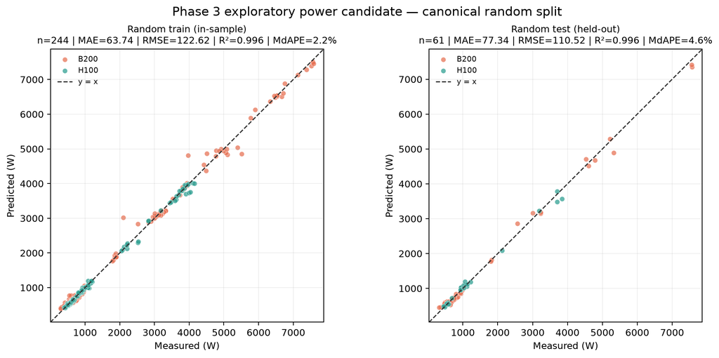

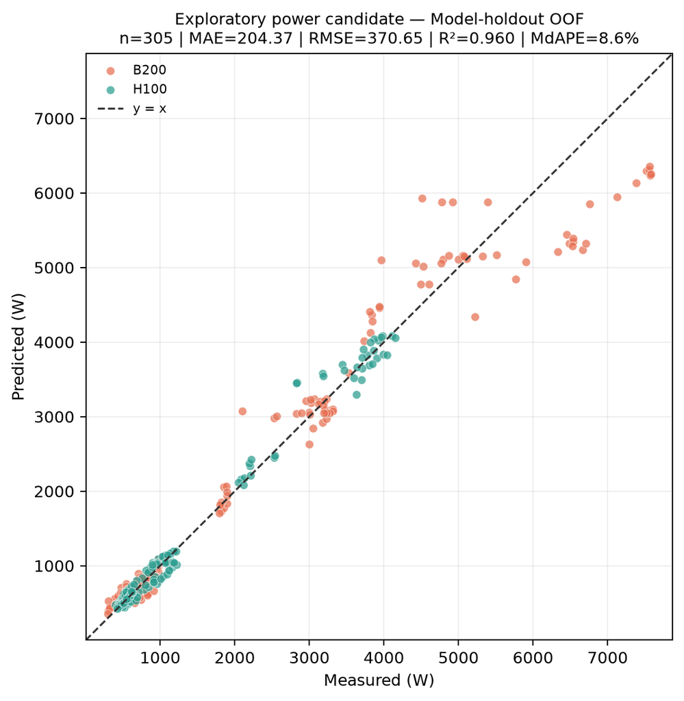

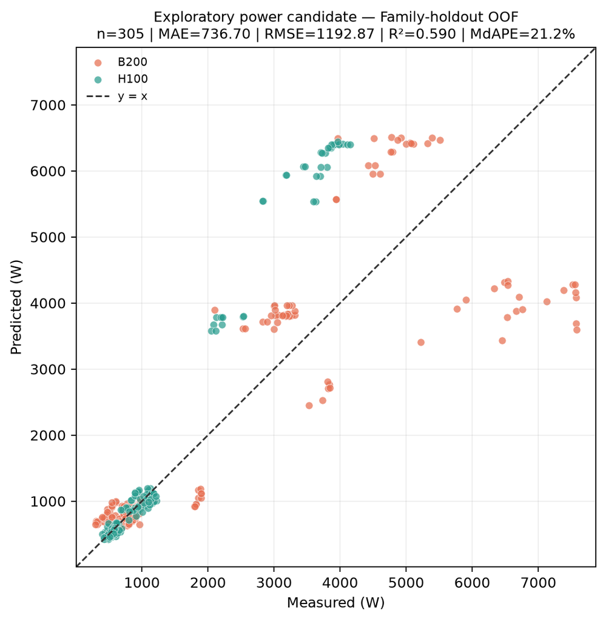

```python
ladder = (
    generalization.groupby(["model_variant", "split_scheme"], as_index=False)
    .agg(runs=("mae", "size"), mae_mean=("mae", "mean"), mae_std=("mae", "std"), r2_mean=("r2", "mean"))
)
display(ladder.round(3))
for name in (
    "actual_vs_predicted_random_best.png",
    "actual_vs_predicted_model_holdout_best.png",
    "actual_vs_predicted_family_holdout_best.png",
):
    display(Image(filename=str(FIGURES / name), width=1000))
```

## Hardware and target strategies

B4 continuous hardware fields show a suggestive observed improvement for the outcome-informed XGBoost follow-up, but its B3→B4 paired interval crosses zero. B5 workload/hardware pressure ratios degrade that candidate. Removing the categorical GPU label from B5 changes MAE only modestly and with an interval spanning zero; with only two hardware classes, continuous fields cannot be interpreted as validated cross-GPU scaling laws. The rated-power-fraction target also underperforms direct B4 power prediction.

```python
display(hardware.round(3))
display(hardware_pairs.round(3))
display(strategies.round(3))
```

|  | target | bundle | model_name | analysis_role | split_scheme | retains_gpu_label | n_rows | mae | rmse | r2 | ... | rmse_ci_high | r2_ci_low | r2_ci_high | mdape_percent_ci_low | mdape_percent_ci_high | smape_percent_ci_low | smape_percent_ci_high | negative_prediction_count | minimum_prediction | backend_module |
| --- | --- | --- | --- | --- | --- | --- | --- | --- | --- | --- | --- | --- | --- | --- | --- | --- | --- | --- | --- | --- | --- |
| 0 | y_gpu_avg_power_watts | B3-Physics | XGBoost | outcome_informed_exploratory_followup | model_group | True | 305 | 237.866 | 379.592 | 0.958 | ... | 529.213 | 0.940 | 0.967 | 8.947 | 12.700 | 10.790 | 14.385 | 0 | 375.275 | xgboost.sklearn |
| 1 | y_gpu_avg_power_watts | B4-Hardware | XGBoost | outcome_informed_exploratory_followup | model_group | True | 305 | 204.366 | 370.649 | 0.960 | ... | 536.273 | 0.941 | 0.976 | 6.088 | 11.414 | 8.278 | 13.000 | 0 | 357.439 | xgboost.sklearn |
| 2 | y_gpu_avg_power_watts | B5-HardwarePhysics | XGBoost | outcome_informed_exploratory_followup | model_group | True | 305 | 241.746 | 443.548 | 0.943 | ... | 660.564 | 0.909 | 0.970 | 6.525 | 13.077 | 9.889 | 14.495 | 0 | 391.333 | xgboost.sklearn |
| 3 | y_gpu_avg_power_watts | B5-HardwarePhysics-NoLabel | XGBoost | outcome_informed_exploratory_followup | model_group | False | 305 | 233.969 | 426.945 | 0.947 | ... | 623.162 | 0.918 | 0.977 | 6.573 | 12.750 | 9.674 | 14.481 | 0 | 391.333 | xgboost.sklearn |

4 rows × 27 columns

|  | reference_variant | candidate_variant | analysis_role | n_rows | n_model_clusters | mae_reference | mae_candidate | row_weighted_mae_delta_candidate_minus_reference | equal_model_mae_delta_candidate_minus_reference | equal_model_mae_delta_ci_low | equal_model_mae_delta_ci_high | bootstrap_replicates |
| --- | --- | --- | --- | --- | --- | --- | --- | --- | --- | --- | --- | --- |
| 0 | B0-Core__HistGradientBoosting | B4-Hardware__XGBoost | outcome_informed_exploratory_comparison | 305 | 14 | 253.287 | 204.366 | -48.921 | -66.848 | -129.495 | -20.401 | 1000 |
| 1 | B3-Physics__XGBoost | B4-Hardware__XGBoost | outcome_informed_exploratory_comparison | 305 | 14 | 237.866 | 204.366 | -33.500 | -24.809 | -55.476 | 9.985 | 1000 |
| 2 | B4-Hardware__XGBoost | B5-HardwarePhysics__XGBoost | outcome_informed_exploratory_comparison | 305 | 14 | 204.366 | 241.746 | 37.380 | 49.941 | 10.987 | 105.665 | 1000 |
| 3 | B5-HardwarePhysics__XGBoost | B5-HardwarePhysics-NoLabel__XGBoost | outcome_informed_exploratory_comparison | 305 | 14 | 241.746 | 233.969 | -7.777 | -4.180 | -23.708 | 8.746 | 1000 |

|  | target | bundle | model_name | split_scheme | target_transform | target_strategy | n_rows | mae | rmse | r2 | mdape_percent | smape_percent | nonfinite_prediction_count | negative_prediction_count | minimum_prediction | maximum_prediction | backend_module |
| --- | --- | --- | --- | --- | --- | --- | --- | --- | --- | --- | --- | --- | --- | --- | --- | --- | --- |
| 0 | y_gpu_avg_power_watts | B4-Hardware | XGBoost | model_group | raw | direct | 305 | 204.366 | 370.649 | 0.960 | 8.573 | 10.509 | 0 | 0 | 357.439 | 6357.155 | xgboost.sklearn |
| 1 | y_gpu_avg_power_watts | B4-Hardware | XGBoost | model_group | raw | power_fraction | 305 | 239.824 | 416.206 | 0.950 | 9.323 | 12.402 | 0 | 0 | 392.560 | 7292.863 | xgboost.sklearn |
| 2 | y_gpu_energy_per_token_joules | B1-Static | XGBoost | model_group | log1p | direct | 305 | 0.650 | 2.113 | 0.677 | 24.425 | 29.747 | 0 | 0 | 0.053 | 12.654 | xgboost.sklearn |
| 3 | y_gpu_energy_per_token_joules | B1-Static | XGBoost | model_group | raw | direct | 305 | 0.620 | 2.114 | 0.677 | 24.213 | 29.565 | 0 | 1 | -0.021 | 11.914 | xgboost.sklearn |

## Error analysis and interpretation

Fold-local permutation importance and PDP use models fitted only on each outer-training fold. SHAP was unavailable in the frozen environment. Aggregate rated power, GPU count, and model parameter count dominate B4 importance, but wide fold-to-fold error bars and separated PDP curves show instability. Load-regime bins use post-run information for diagnosis only and never enter X.

|  | feature | importance_mae_increase_mean |
| --- | --- | --- |
| 4 | x_hardware_aggregate_rated_power_w | 413.189 |
| 9 | x_hardware_num_gpus | 361.248 |
| 18 | x_model_benchmark_total_params_billions | 244.186 |
| 2 | x_deployment_max_num_seqs | 56.871 |
| 1 | x_deployment_expert_parallel | 21.894 |
| 37 | x_physics_prefill_projection_flop_per_request | 11.754 |
| 43 | x_workload_effective_input_tokens_mean | 8.285 |
| 16 | x_model_benchmark_activated_params_billions | 7.260 |
| 12 | x_hardware_precision_matched_peak_compute_tflops | 6.652 |
| 10 | x_hardware_peak_compute_bf16_dense_tflops | 5.910 |
| 45 | x_workload_effective_input_tokens_p50 | 5.871 |
| 40 | x_physics_weight_bytes_per_gpu_ideal | 4.333 |
| 27 | x_model_num_layers | 2.551 |
| 35 | x_physics_prefill_attention_flop_per_request | 2.080 |
| 11 | x_hardware_peak_compute_fp8_dense_tflops | 1.909 |

|  | target | bundle | model_name | split_scheme | slice_type | slice_value | n_rows | n_models | mae | rmse | r2 | mdape_percent | smape_percent |
| --- | --- | --- | --- | --- | --- | --- | --- | --- | --- | --- | --- | --- | --- |
| 0 | y_gpu_avg_power_watts | B4-Hardware | XGBoost | model_group | gpu_model | B200 | 166 | 14 | 292.895 | 486.867 | 0.949 | 8.722 | 12.034 |
| 1 | y_gpu_avg_power_watts | B4-Hardware | XGBoost | model_group | gpu_model | H100 | 139 | 12 | 98.640 | 135.514 | 0.987 | 8.301 | 8.687 |
| 2 | y_gpu_avg_power_watts | B4-Hardware | XGBoost | model_group | model_family | Gemma-3 | 29 | 2 | 55.830 | 68.493 | 0.898 | 5.406 | 7.206 |
| 3 | y_gpu_avg_power_watts | B4-Hardware | XGBoost | model_group | model_family | Qwen3 | 226 | 9 | 145.956 | 237.469 | 0.974 | 7.368 | 10.229 |
| 4 | y_gpu_avg_power_watts | B4-Hardware | XGBoost | model_group | model_family | Qwen3-Coder | 50 | 3 | 554.530 | 761.848 | 0.925 | 14.130 | 13.691 |
| 12 | y_gpu_avg_power_watts | B4-Hardware | XGBoost | model_group | load_regime | 0.95_to_0.99 | 18 | 8 | 403.471 | 626.220 | 0.937 | 12.030 | 13.208 |
| 13 | y_gpu_avg_power_watts | B4-Hardware | XGBoost | model_group | load_regime | at_or_above_0.99 | 264 | 14 | 181.759 | 328.945 | 0.965 | 8.048 | 10.211 |
| 14 | y_gpu_avg_power_watts | B4-Hardware | XGBoost | model_group | load_regime | below_0.95 | 23 | 10 | 308.026 | 522.380 | 0.943 | 7.384 | 11.821 |
| 15 | y_gpu_energy_per_token_joules | B1-Static | XGBoost | model_group | gpu_model | B200 | 166 | 14 | 0.957 | 2.832 | 0.616 | 24.703 | 31.730 |
| 16 | y_gpu_energy_per_token_joules | B1-Static | XGBoost | model_group | gpu_model | H100 | 139 | 12 | 0.218 | 0.482 | 0.949 | 24.097 | 26.979 |
| 17 | y_gpu_energy_per_token_joules | B1-Static | XGBoost | model_group | model_family | Gemma-3 | 29 | 2 | 0.125 | 0.176 | 0.804 | 23.816 | 28.439 |
| 18 | y_gpu_energy_per_token_joules | B1-Static | XGBoost | model_group | model_family | Qwen3 | 226 | 9 | 0.252 | 0.557 | 0.937 | 20.668 | 24.988 |
| 19 | y_gpu_energy_per_token_joules | B1-Static | XGBoost | model_group | model_family | Qwen3-Coder | 50 | 3 | 2.570 | 5.084 | 0.482 | 34.752 | 50.904 |
| 27 | y_gpu_energy_per_token_joules | B1-Static | XGBoost | model_group | load_regime | 0.95_to_0.99 | 18 | 8 | 0.840 | 2.169 | 0.565 | 26.668 | 33.812 |
| 28 | y_gpu_energy_per_token_joules | B1-Static | XGBoost | model_group | load_regime | at_or_above_0.99 | 264 | 14 | 0.481 | 1.748 | 0.702 | 23.865 | 28.622 |
| 29 | y_gpu_energy_per_token_joules | B1-Static | XGBoost | model_group | load_regime | below_0.95 | 23 | 10 | 2.051 | 4.529 | 0.609 | 29.863 | 37.065 |

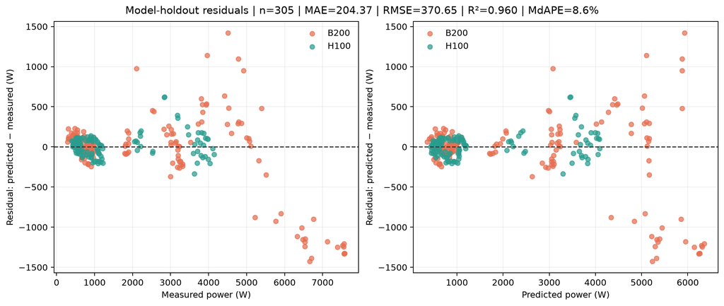

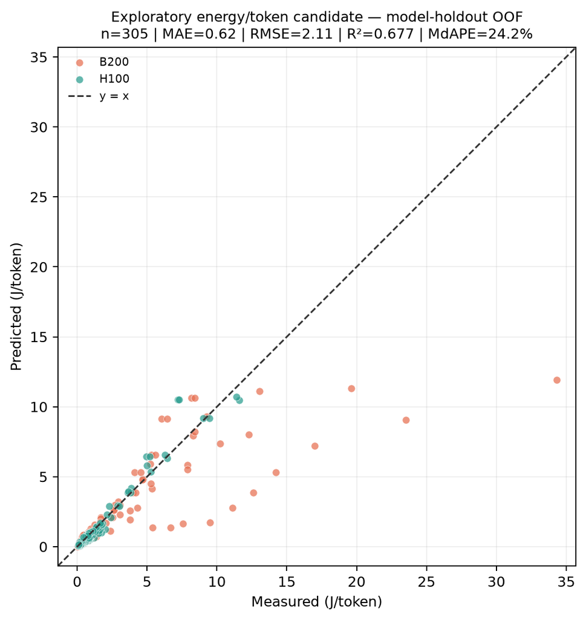

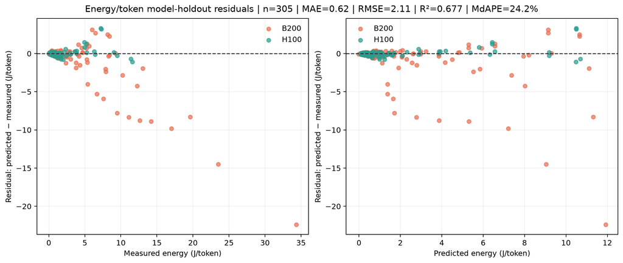

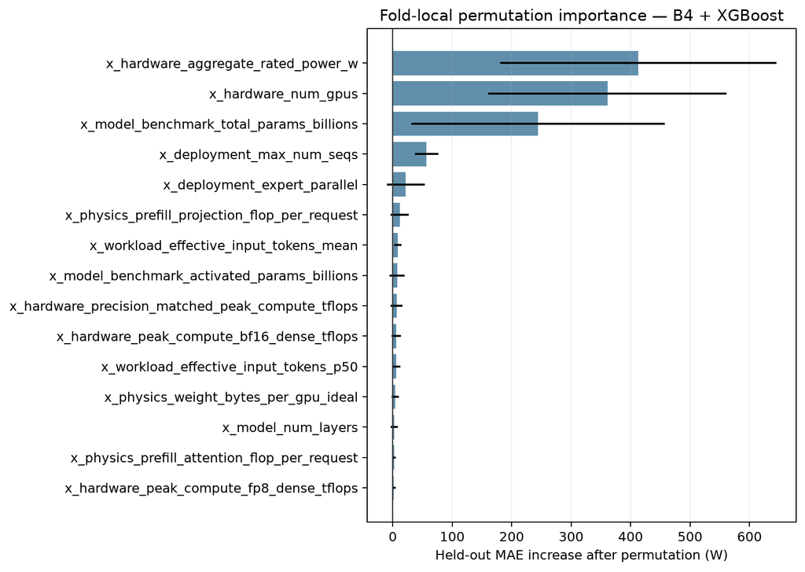

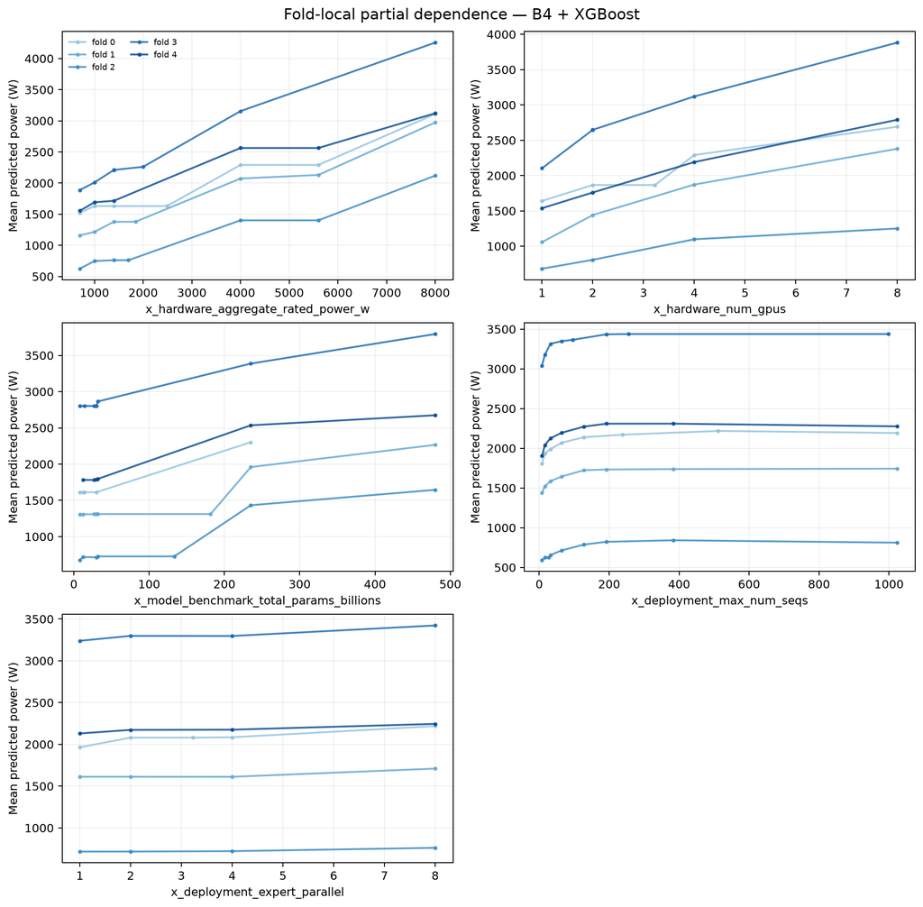

```python
best_importance = (
    importance.loc[importance["model_variant"].eq("B4-Hardware__XGBoost")]
    .groupby("feature", as_index=False)["importance_mae_increase_mean"].mean()
    .sort_values("importance_mae_increase_mean", ascending=False)
)
display(best_importance.head(15).round(3))
display(slices.loc[slices["slice_type"].isin(["gpu_model", "model_family", "load_regime"])].round(3))
for name in (
    "residuals_model_holdout_best.png",
    "actual_vs_predicted_energy_best.png",
    "residuals_energy_best.png",
    "feature_importance_best.png",
    "partial_dependence_best.png",
):
    display(Image(filename=str(FIGURES / name), width=1000))
```

## RQ1–RQ5 conclusions

1. **RQ1 — algorithm ceiling:** The matrix can identify the lowest observed outer-test error, but it cannot provide an unbiased algorithm ceiling because the same outer-test results were inspected across many candidates. B4 + XGBoost is retained only as an outcome-informed exploratory candidate (204.4 W MAE, R² 0.960).
2. **RQ2 — why B3 did not help reliably:** XGBoost alone gains 16.8 W from B2b→B3, with a paired interval spanning zero; most other learners worsen. Combined with PCA concentration and correlated proxies, this points to representation/redundancy and limited support, not simply an HGB limitation.
3. **RQ3 — hardware physics:** B4 shows a 33.5 W row-weighted improvement over B3 for exploratory XGBoost, but the equal-model paired interval includes zero. This is suggestive, not stable evidence of incremental value. B5 worsens B4 for that candidate; two GPU points do not identify portable hardware effects.
4. **RQ4 — degradation with difficulty:** The exploratory B4 + XGBoost candidate moves from 97.2 W random mean to 94.7 W config, 204.4 W model, and 736.7 W family MAE. Config has 303 groups for 305 rows (301 singleton groups), so it is nearly run-level and not a strong distinct generalization tier.
5. **RQ5 — applicability:** conclusions support ex-ante prediction of aggregate GPU-side power and energy/token for this high-load steady-state benchmark population. They do not support arbitrary request-rate P(λ), transient power, unseen accelerator families, CPU/DRAM/node residuals, training, or diffusion.

Stop condition: this notebook closes Phase 3.0. Further algorithms, datasets, and dynamic-load modeling require a separately reviewed next phase.